# Hub messaging: show the operator the supervisor's turns, not the pane

Design study · 2026-09-18 · hub conversation · for the operator

Build the Ledger: the supervisor's typed turns on a ruled timeline, the pane one tap away. Desk and Brief stay live.

Why: it is the surface the operator described — my messages and the supervisor's to me — it keeps history and elapsed time visible, and it needs one new field on an envelope that already exists. Today's mirror is six parts traffic to one part message.

- 15supervisor prose
- 3your directives
- 82tool traffic and injected mail

**Of every 100 things a supervisor pane prints, 15 are the supervisor's prose.** 5,155 content blocks from three real cas-src supervisor sessions (2026-09-10 → 2026-09-18), classified by `measure-pane.py`; by character count prose is 2.4 %. Exact counts in the ledger below.

source: measure-pane.py over three Claude Code supervisor transcripts · captured 2026-09-18 16:05 · worktree factory/calm-stork-91 · markdown twin: 2026-09-18-hub-messaging-study.md

> When I'm interacting with the hub I only care about the messages the supervisor is sending me. It should just be my messages and the supervisor messages to me giving me statuses or answering a question. There's no need to stream the whole terminal if we can know which messages the supervisor intends for us.

The direction above (Daniel, 2026-09-18) is a design question and a protocol question. This study answers both: it measures what the pane mirror delivers, collects twenty-eight messaging and activity-feed interfaces as real captures, proposes a six-kind message taxonomy, draws three genuinely different surfaces for it — **Ledger**, **Desk** and **Brief** — at 1280 and 390 px in both schemes, recommends the Ledger, and names the exact code path — with file:line evidence — where a typed supervisor→operator message already half-exists. Nothing is implemented; the closing ledger is the minimal change, and the operator picks the surface before anything is built.

## What the pane delivers today

The hub's conversation view (`hub-web/src/conversation-view.ts`) already draws three things: the operator's own sends (`from-you`), the supervisor's typed replies (`Reply to you`), and then everything the emulator holds as "Live pane text". The third layer is the problem. Three real cas-src supervisor transcripts, classified block by block, put the supervisor's prose at one block in seven.

Pane composition by author. Blocks are content blocks in the Claude Code transcript; 763 hidden thinking blocks are excluded. Source: `measure-pane.py` over the three transcripts, run 2026-09-18 16:05.

| Session (start) | Supervisor prose | Your directives | Tool calls | Tool results | Injected worker / director mail | Visible blocks | Prose share |
| --- | --- | --- | --- | --- | --- | --- | --- |
| `151fbf3a` (2026-09-18) | 15 | 6 | 52 | 52 | 4 | 129 | 11.6 % |
| `2ebdfca9` (2026-09-11) | 135 | 30 | 308 | 308 | 83 | 864 | 15.6 % |
| `35cbdf1a` (2026-09-10) | 619 | 133 | 1,466 | 1,466 | 478 | 4,162 | 14.9 % |
| Pooled | 769 | 169 | 1,826 | 1,826 | 565 | 5,155 | 14.9 % |
| Pooled, by characters | 125,171 | 56,753 | 926,181 | 3,282,323 | 777,676 | 5,168,104 | 2.4 % |

Two caveats keep the number honest. The harness truncates tool output on screen, so the character share (2.4 %) overstates the noise; the block share (14.9 %) is the fair proxy for rows the pane prints. And "prose" includes the narration a supervisor emits between tool calls ("checking the worker status"), so 14.9 % is an upper bound on text actually addressed to the operator. Either way the operator's phone receives six or more parts of traffic for every part of message.

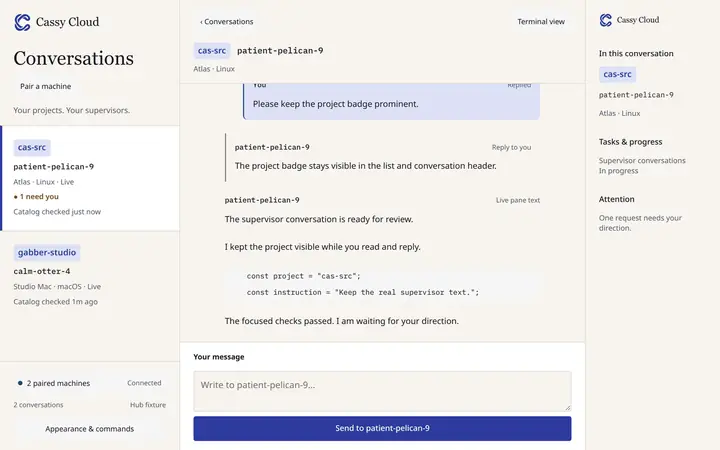

1280 · light Desktop, light: an operator turn, one typed reply, then the raw pane text.

[figure not shown]

390 · dark Phone, dark: the same thread; the pane text is the bulk of the column.

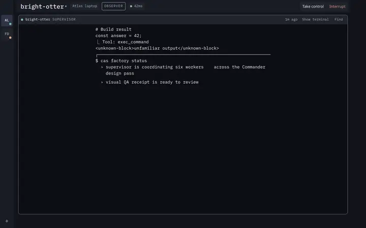

Transcript · 1280 · dark The transcript view: the emulator reflowed, nothing addressed to anyone.

[figure not shown]

390 · light Phone, light, before any operator turn: only pane text.

Real renders of the checked-in fixtures (`hub-web/fixtures/conversations.ts`) through `capture-today.mjs`, worktree tip at capture time; the fixture pane text is the fixture's own.

The captures above are the checked-in fixture states, not a mock: the `from-you` block is the only distinct voice, the one typed reply is styled as a quotation, and the pane text below both carries no addressee at all.

## The reference interfaces

Twenty-eight real captures, each judged on what a status-heavy, asymmetric conversation can steal from it. Consumer chat, team chat, AI-assistant chat, ops and status feeds, and six unconventional readers. Click a frame to enlarge it.

[figure not shown]

01 · Apple Messages (macOS) · consumer

**Does well**

A tiny sender label over the bubble; reactions pinned to a corner; sidebar rows carry the last line.

**Does badly**

Ownership by colour alone; no state beyond delivered; photos dominate the column.

**Stealable**

Corner chips as cheap receipts (`acked`, `merged`); the sender label as a kind label.

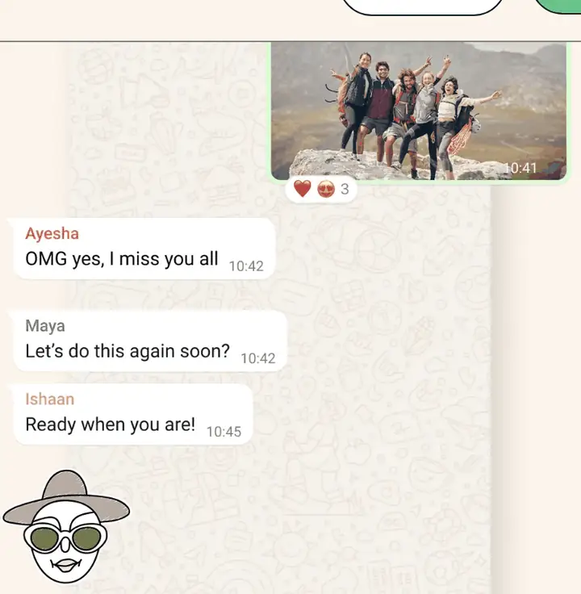

02 · WhatsApp (group) · consumer

**Does well**

Colour on the name, not the bubble; time tucked inside; read state inline.

**Does badly**

Marketing crop; no threading; consecutive messages are not grouped.

**Stealable**

Tick-state in the corner of a directive as its delivery receipt.

[figure not shown]

03 · Signal (Android) · consumer

**Does well**

The centred low-contrast system line sits inside the flow without looking like a message.

**Does badly**

Very dense metadata in every bubble; no reply threading.

**Stealable**

The system line is the shape of a status row between turns.

[figure not shown]

04 · Telegram (public channel, live) · consumer

**Does well**

Each post is self-contained with a footer; previews render as bordered quote-cards; long posts stay readable.

**Does badly**

One-way; unbounded post height; a busy decorative background.

**Stealable**

The bordered preview card as the container for a receipt or a table inside a message.

[figure not shown]

05 · Slack (channel and thread) · team

**Does well**

The badge separates automation from people; the reply-count row folds a thread; channel and thread side by side.

**Does badly**

Placeholder thread bodies; two composers compete on one screen.

**Stealable**

A badge on the sender plus a reply-count row: mark the supervisor's turn and fold worker chatter.

[figure not shown]

06 · Discord (new thread) · team

**Does well**

The flattest possible message anatomy: avatar, name, time, body on one baseline.

**Does badly**

Only one message; a blurry support-article frame; no status affordances.

**Stealable**

Name and `Today at HH:MM` on one line with the body under it — the densest readable row.

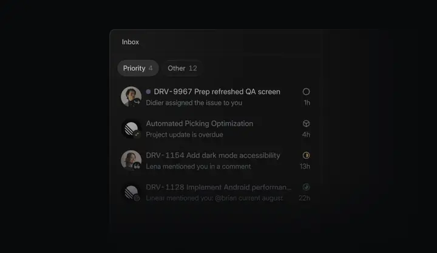

07 · Linear Inbox · team

**Does well**

Row = what + why + state; unread dots; triage tabs with counts.

**Does badly**

A list, not a conversation; low-contrast dark render; truncated titles.

**Stealable**

The two-line row (what, why, glyph, age) for the Desk queue and the Ledger's list row.

[figure not shown]

08 · Height (task chat with Copilot) · team

**Does well**

Attributes and chat side by side; the AI is a named participant with an explicit addressee.

**Does badly**

Third-party review capture; the AI reply is unbounded prose; no receipts.

**Stealable**

The `A → B` addressing label — `↩ your 09:56` on an answer.

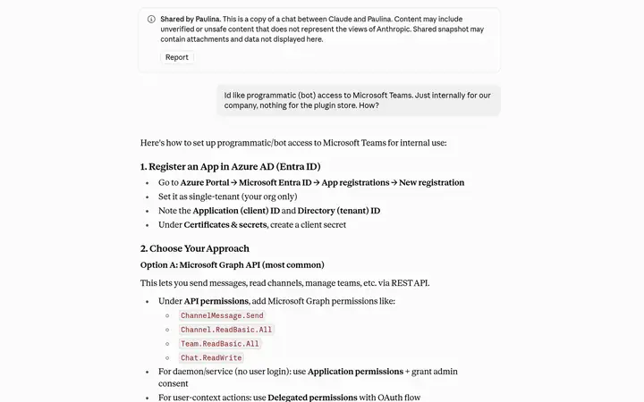

09 · Claude.ai (shared chat, live) · AI assistant

**Does well**

The assistant's turn is a document, not a bubble; strong type hierarchy.

**Does badly**

No timestamps, no state, no sender labels; long replies scroll forever.

**Stealable**

Asymmetric turns: short directives as blocks, supervisor output as structured reading.

[figure not shown]

10 · ChatGPT (shared chat, live) · AI assistant

**Does well**

Long input collapses by default; attachments are chips; the verdict leads the detail.

**Does badly**

Sidebar chrome eats width; no per-message time; no sign of work in progress.

**Stealable**

Lead every receipt with a one-line verdict; collapse long payloads.

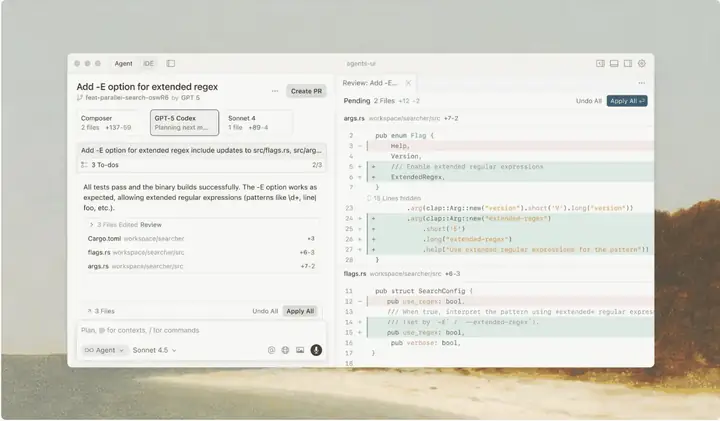

11 · Cursor 2.0 agent · AI assistant

**Does well**

Every status is quantified; the diff sits beside the conversation; "Create PR" is one button.

**Does badly**

Marketing render; no timestamps; the human's turn is a one-line card, easy to lose.

**Stealable**

The quantified receipt: to-do counter, files, +/− per file.

[figure not shown]

12 · Devin session · AI assistant

**Does well**

Work folds into one row; PR cards are first-class receipts; an explicit idle line.

**Does badly**

Marketing composite; no timestamps; a wide horizontal layout.

**Stealable**

Fold the work, show the outcome; an explicit hand-back line.

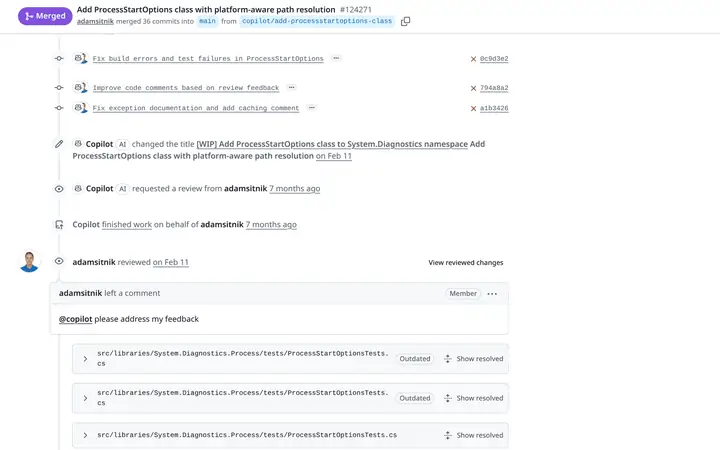

13 · GitHub Copilot coding-agent PR (live) · AI assistant

**Does well**

One-line events with icons; the `AI` badge beside the actor; commits carry SHA and CI state; resolved threads collapse.

**Does badly**

Commits, events and comments mix with little grouping; a wide empty gutter.

**Stealable**

The one-line event row (icon · actor · verb · object · time) as the receipt row.

[figure not shown]

15 · Vercel runtime logs · ops feed

**Does well**

One row per event in fixed columns; repeats collapse into a count badge; live counts in the rail.

**Does badly**

Every row has the same weight; the row that matters relies on status colour.

**Stealable**

The monospace receipt row and the count badge for repeated statuses.

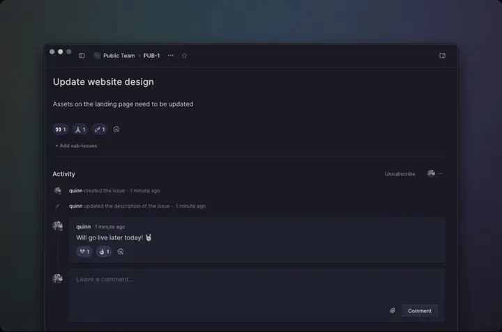

16 · Linear issue activity · ops feed

**Does well**

Two tiers on one rail: system events as one muted line, human comments as full cards.

**Does badly**

System events carry no payload or link; the rail connector is faint.

**Stealable**

Two-tier feed: hairline status rows between full turns.

[figure not shown]

17 · Sentry issue details · ops feed

**Does well**

State lives in a persistent header; the activity rail is compact and collapses noise.

**Does badly**

Six zones compete on one screen; the docs figure carries annotation labels.

**Stealable**

A sticky state header over the conversation; an "N hidden" collapser for repeats.

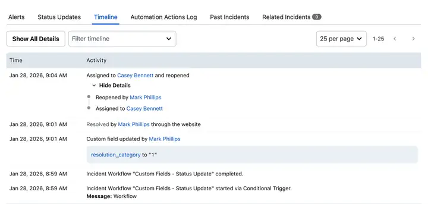

18 · PagerDuty incident timeline · ops feed

**Does well**

A fixed timestamp column; compound events as one expandable row; verbs colour-coded with words.

**Does badly**

Newest-first with no phase grouping; human and automation differ only by wording.

**Stealable**

The table-shaped timeline with a fixed time column and expandable compound rows.

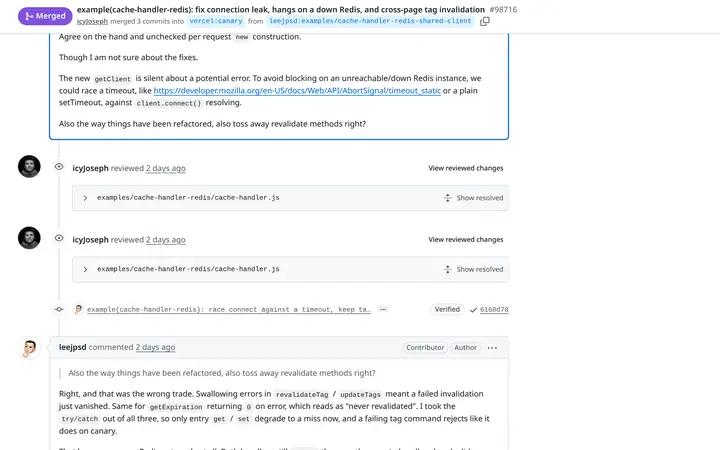

19 · GitHub PR conversation (live) · ops feed

**Does well**

Three densities on one rail; a sticky outcome header; role badges beside names.

**Does badly**

Review rows near-duplicate; commit rows are easy to miss; quoted replies eat space.

**Stealable**

The condensed commit row (message · chip · SHA) as the merge receipt; role badges.

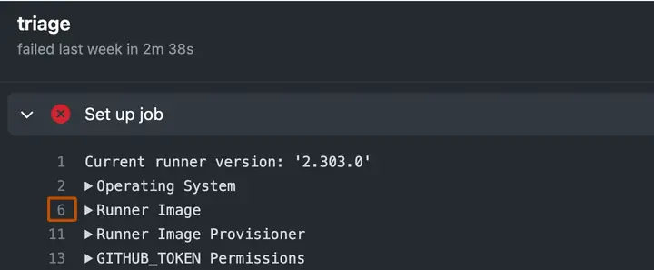

20 · GitHub Actions job log · ops feed

**Does well**

Only the failure opens; steps carry status, name and duration; lines are numbered and linkable.

**Does badly**

A cropped documentation figure with an annotation box; no timestamps.

**Stealable**

Collapsible steps where only the failure auto-expands; numbered lines a verdict can cite.

[figure not shown]

21 · incident.io (Slack channel) · ops feed

**Does well**

Directive → status → decision → recorded delta → suggestion with buttons, in one flow.

**Does badly**

A marketing composite; no timestamps; unrealistically terse.

**Stealable**

The inline state-delta line and next-step buttons attached to the supervisor's turn.

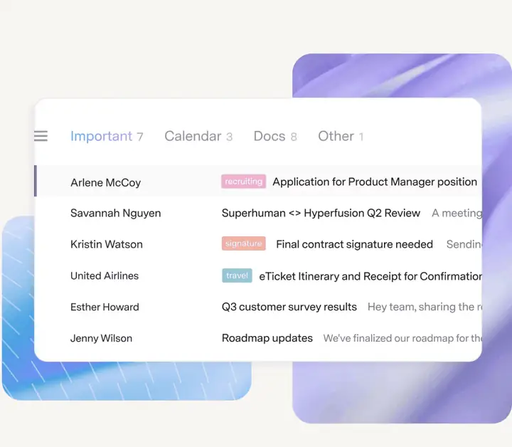

22 · Superhuman split inbox · unconventional

**Does well**

Tabs with counts turn one inbox into lanes; chips sit inline before the subject.

**Does badly**

Marketing crop; no timestamps or unread marks; the right edge truncates.

**Stealable**

Lanes with counts for the feed (Needs you · Receipts · Statuses).

[figure not shown]

23 · HEY Imbox · unconventional

**Does well**

One band separates unseen from seen; very high contrast; dates only.

**Does badly**

Every row looks alike; no threading or state; dates out of order.

**Stealable**

A "new for you" divider between unread supervisor turns and the rest.

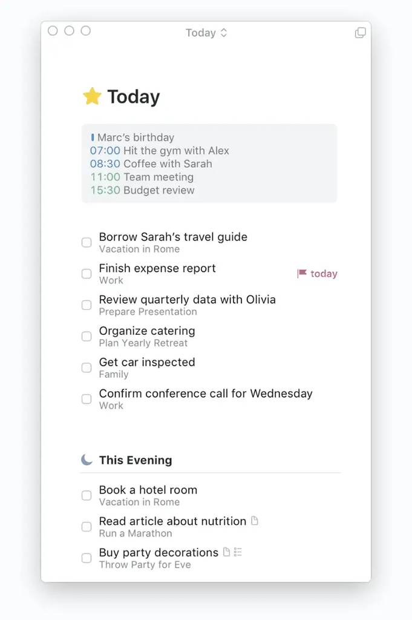

24 · Things 3 Today · unconventional

**Does well**

Two-line rows; today's context as a tinted block; one flag is the only alert; whitespace groups.

**Does badly**

No timestamps or ownership; no in-progress state.

**Stealable**

One reserved flag for the item that needs the human today.

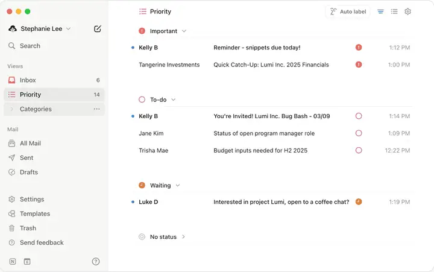

25 · Notion Mail priority view · unconventional

**Does well**

State groups with icons are the primary structure; headers collapse; the glyph repeats per row.

**Does badly**

Large gaps; a generic status vocabulary; no preview text.

**Stealable**

Group the feed by state with collapsible headers and a per-row glyph and time.

[figure not shown]

26 · Apple Journal · unconventional

**Does well**

Each entry is a card with a mosaic, title, body and date; system data rendered as tiles inside it.

**Does badly**

Half the frame is onboarding; tall cards; no actor, no state.

**Stealable**

An evidence mosaic (test-run tile, diff tile, PR tile) at the top of a receipt.

[figure not shown]

27 · Arc browser · unconventional

**Does well**

The sidebar is the whole navigation: spaces, folders, pinned and active in one column.

**Does badly**

No state or counts in the sidebar; folders and tabs look alike.

**Stealable**

The active conversation as the highlighted tab of a tinted workspace column.

[figure not shown]

28 · Zulip #design (live web-public) · team

**Does well**

Every message sits under a topic so one channel reads as many small threads; the composer names where the reply lands.

**Does badly**

Repeated headers interrupt flow; a long truncated topic list.

**Stealable**

Topic-bar chunking per task thread; a composer that names its target.

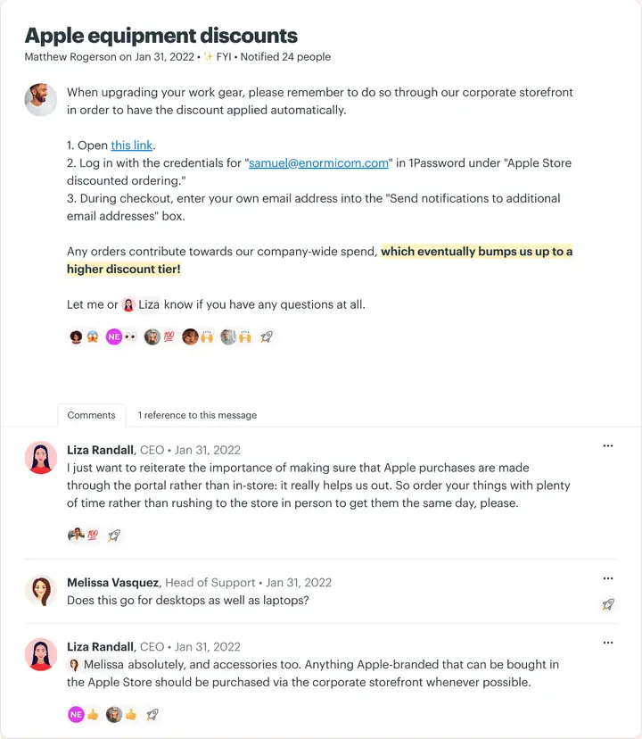

29 · Basecamp message board · team

**Does well**

The byline encodes type and audience; roles next to names; comments counted and separated.

**Does badly**

Static marketing image; no state or resolution on the post.

**Stealable**

A type-and-audience byline (`Receipt · notified you`) and role tags after names.

**The same twenty-plus references as a table**

References — 28 real captures under `refs/` (`NN-slug.png`), one line each on what it does well, what it does badly, and the pattern worth stealing for a status-heavy agent↔human conversation. Live captures are noted; the rest are vendors' own product or documentation images.

| # | Product | Category | What the frame shows | Does well | Does badly | Stealable pattern |
| --- | --- | --- | --- | --- | --- | --- |
| 01 | Apple Messages (macOS) | consumer | A group chat with sidebar previews, blue and grey bubbles, a sender name over each bubble, a tapback heart and a photo bubble. | A tiny sender label over the bubble; reactions pinned to a corner; sidebar rows carry the last line. | Ownership by colour alone; no state beyond delivered; photos dominate the column. | Corner chips as cheap receipts (`acked`, `merged`); the sender label as a kind label. |
| 02 | WhatsApp (group) | consumer | Incoming bubbles with coloured sender names, in-bubble timestamps, a photo with a reaction count and double blue ticks. | Colour on the name, not the bubble; time tucked inside; read state inline. | Marketing crop; no threading; consecutive messages are not grouped. | Tick-state in the corner of a directive as its delivery receipt. |
| 03 | Signal (Android) | consumer | A dark chat with a centred system notice ("Maya set the disappearing message timer"), a voice-note bubble and in-bubble time and state icons. | The centred low-contrast system line sits inside the flow without looking like a message. | Very dense metadata in every bubble; no reply threading. | The system line is the shape of a status row between turns. |
| 04 | Telegram (public channel, live) | consumer | A live channel feed: bold channel name per post, a bordered link-preview card, a view count and time on every post. | Each post is self-contained with a footer; previews render as bordered quote-cards; long posts stay readable. | One-way; unbounded post height; a busy decorative background. | The bordered preview card as the container for a receipt or a table inside a message. |
| 05 | Slack (channel and thread) | team | A channel with an embedded canvas card, a `WORKFLOW`-badged bot post with an avatar stack and "3 replies", and the thread pane beside it. | The badge separates automation from people; the reply-count row folds a thread; channel and thread side by side. | Placeholder thread bodies; two composers compete on one screen. | A badge on the sender plus a reply-count row: mark the supervisor's turn and fold worker chatter. |
| 06 | Discord (new thread) | team | A thread being created: title field, one starter message (avatar, name, "Today at 11:26 AM", text) and a composer. | The flattest possible message anatomy: avatar, name, time, body on one baseline. | Only one message; a blurry support-article frame; no status affordances. | Name and `Today at HH:MM` on one line with the body under it — the densest readable row. |
| 07 | Linear Inbox | team | An inbox with Priority and Other tabs; two-line rows: issue ID and title, then the reason ("Didier assigned the issue to you"), age and a status glyph. | Row = what + why + state; unread dots; triage tabs with counts. | A list, not a conversation; low-contrast dark render; truncated titles. | The two-line row (what, why, glyph, age) for the Desk queue and the Ledger's list row. |
| 08 | Height (task chat with Copilot) | team | A task's attribute table (Status, Assignees, Lists) beside a chat pane where "Melika to Copilot" and "Copilot to you" label each turn. | Attributes and chat side by side; the AI is a named participant with an explicit addressee. | Third-party review capture; the AI reply is unbounded prose; no receipts. | The `A → B` addressing label — `↩ your 09:56` on an answer. |
| 09 | Claude.ai (shared chat, live) | AI assistant | A shared conversation: a compact right-aligned user bubble, then the reply as a full-width serif document with headings, bullets and code chips. | The assistant's turn is a document, not a bubble; strong type hierarchy. | No timestamps, no state, no sender labels; long replies scroll forever. | Asymmetric turns: short directives as blocks, supervisor output as structured reading. |
| 10 | ChatGPT (shared chat, live) | AI assistant | A shared chat with a "Today 6:55 AM" divider, an "Uploaded a file" chip, a `Show more` truncation, then a reply that opens with a bold verdict before a code block. | Long input collapses by default; attachments are chips; the verdict leads the detail. | Sidebar chrome eats width; no per-message time; no sign of work in progress. | Lead every receipt with a one-line verdict; collapse long payloads. |
| 11 | Cursor 2.0 agent | AI assistant | An agent window: task title, branch, model cards with file counts and +/−, `3 To-dos 2/3`, a status sentence, a "3 Files Edited" list and a diff pane. | Every status is quantified; the diff sits beside the conversation; "Create PR" is one button. | Marketing render; no timestamps; the human's turn is a one-line card, easy to lose. | The quantified receipt: to-do counter, files, +/− per file. |
| 12 | Devin session | AI assistant | A session: the user's directive, `Used playbook: Test`, a collapsible `Worked for 4m 13s +25 −131`, two PR cards, "Done! Full report attached", and "Devin is ready for instructions". | Work folds into one row; PR cards are first-class receipts; an explicit idle line. | Marketing composite; no timestamps; a wide horizontal layout. | Fold the work, show the outcome; an explicit hand-back line. |
| 13 | GitHub Copilot coding-agent PR (live) | AI assistant | A real PR timeline: three Copilot commits with SHAs and red check marks, `Copilot [AI] changed the title`, "finished work on behalf of adamsitnik", then the human's "@copilot please address my feedbac… | One-line events with icons; the `AI` badge beside the actor; commits carry SHA and CI state; resolved threads collapse. | Commits, events and comments mix with little grouping; a wide empty gutter. | The one-line event row (icon · actor · verb · object · time) as the receipt row. |
| 15 | Vercel runtime logs | ops feed | A logs table: time to the centisecond, method, status chip, host, path, a message with a count badge, and a filter rail with warning and error counts. | One row per event in fixed columns; repeats collapse into a count badge; live counts in the rail. | Every row has the same weight; the row that matters relies on status colour. | The monospace receipt row and the count badge for repeated statuses. |
| 16 | Linear issue activity | ops feed | An issue's Activity rail: muted one-line system events ("quinn created the issue · 1 minute ago") interleaved with a full comment card and a pinned composer. | Two tiers on one rail: system events as one muted line, human comments as full cards. | System events carry no payload or link; the rail connector is faint. | Two-tier feed: hairline status rows between full turns. |
| 17 | Sentry issue details | ops feed | An issue page: header with counts, a workflow bar (Resolve, Archive, Priority, Assignee), stack trace, and a right-rail Activity with "Assigned to Keith Ryan 10:30 AM" and "4 comments hidden". | State lives in a persistent header; the activity rail is compact and collapses noise. | Six zones compete on one screen; the docs figure carries annotation labels. | A sticky state header over the conversation; an "N hidden" collapser for repeats. |
| 18 | PagerDuty incident timeline | ops feed | A Time / Activity table: "Assigned to Casey Bennett and reopened" with an expanded detail list, "Resolved by …" in green, a tinted key/value block, workflow rows. | A fixed timestamp column; compound events as one expandable row; verbs colour-coded with words. | Newest-first with no phase grouping; human and automation differ only by wording. | The table-shaped timeline with a fixed time column and expandable compound rows. |
| 19 | GitHub PR conversation (live) | ops feed | A merged PR: sticky "Merged" header with the branch pair, review rows with collapsed files, a condensed commit row with a Verified chip and SHA, comments with role badges. | Three densities on one rail; a sticky outcome header; role badges beside names. | Review rows near-duplicate; commit rows are easy to miss; quoted replies eat space. | The condensed commit row (message · chip · SHA) as the merge receipt; role badges. |
| 20 | GitHub Actions job log | ops feed | A failed job: the failed step auto-expanded with numbered log lines and collapsible groups; other steps folded with status icon, name and duration. | Only the failure opens; steps carry status, name and duration; lines are numbered and linkable. | A cropped documentation figure with an annotation box; no timestamps. | Collapsible steps where only the failure auto-expands; numbered lines a verdict can cite. |
| 21 | incident.io (Slack channel) | ops feed | An incident channel: "@incident what's going on?", the APP's bolded impact sentence, a human severity change recorded as `Severity: ~~Minor~~ → Major`, then next-step buttons. | Directive → status → decision → recorded delta → suggestion with buttons, in one flow. | A marketing composite; no timestamps; unrealistically terse. | The inline state-delta line and next-step buttons attached to the supervisor's turn. |
| 22 | Superhuman split inbox | unconventional | A split inbox: tabs with counts (Important 7 · Calendar 3 · Docs 8), rows with sender, label chips, subject and grey preview, a purple bar on the current row. | Tabs with counts turn one inbox into lanes; chips sit inline before the subject. | Marketing crop; no timestamps or unread marks; the right edge truncates. | Lanes with counts for the feed (Needs you · Receipts · Statuses). |
| 23 | HEY Imbox | unconventional | The Imbox: a large title, a "NEW FOR YOU" divider, rows with initials, oversized subjects, sender folded into the preview, orange unread dots. | One band separates unseen from seen; very high contrast; dates only. | Every row looks alike; no threading or state; dates out of order. | A "new for you" divider between unread supervisor turns and the rest. |
| 24 | Things 3 Today | unconventional | Today: a tinted calendar block, two-line to-dos with muted project subtitles, one red `⚑ today` flag, a "This Evening" section. | Two-line rows; today's context as a tinted block; one flag is the only alert; whitespace groups. | No timestamps or ownership; no in-progress state. | One reserved flag for the item that needs the human today. |
| 25 | Notion Mail priority view | unconventional | Priority: collapsible status groups (Important, To-do, Waiting, No status), each row with an unread dot, sender, subject, state glyph and time. | State groups with icons are the primary structure; headers collapse; the glyph repeats per row. | Large gaps; a generic status vocabulary; no preview text. | Group the feed by state with collapsible headers and a per-row glyph and time. |
| 26 | Apple Journal | unconventional | The Journal feed: entry cards with a media mosaic (photo, podcast art, map pin), a bold title, body, a date footer, a "Walk 9 560 steps" tile. | Each entry is a card with a mosaic, title, body and date; system data rendered as tiles inside it. | Half the frame is onboarding; tall cards; no actor, no state. | An evidence mosaic (test-run tile, diff tile, PR tile) at the top of a receipt. |
| 27 | Arc browser | unconventional | Arc's tinted space sidebar — pinned items, a folder, `+ New Tab`, the active tab highlighted, space dots below — beside the page (cropped to remove the site's promotional strip). | The sidebar is the whole navigation: spaces, folders, pinned and active in one column. | No state or counts in the sidebar; folders and tabs look alike. | The active conversation as the highlighted tab of a tinted workspace column. |
| 28 | Zulip #design (live web-public) | team | A live channel chunked by green topic bars ("design › #9312 typeahead…") with messages beneath, a `SHOW MORE` collapser, a TODAY pill, a composer naming the topic. | Every message sits under a topic so one channel reads as many small threads; the composer names where the reply lands. | Repeated headers interrupt flow; a long truncated topic list. | Topic-bar chunking per task thread; a composer that names its target. |
| 29 | Basecamp message board | team | A post with a byline ("Matthew Rogerson · FYI · Notified 24 people"), body with a highlight and a mention chip, a Comments tab beside a "1 reference to this message" tab, and comments with roles after… | The byline encodes type and audience; roles next to names; comments counted and separated. | Static marketing image; no state or resolution on the post. | A type-and-audience byline (`Receipt · notified you`) and role tags after names. |

## The taxonomy

The hub conversation is asymmetric: one human sends short directives and questions; one supervisor sends statuses, verdicts, tables, merge receipts and answers. Chat bubbles equalise every turn. The proposal instead draws the thread as an **annotated timeline**: mono timestamps on a left spine, the elapsed time between a directive and its answer printed on the spine, and a kind eyebrow on every supervisor turn. Six kinds cover everything the supervisor says to the operator; a seventh line, *working*, is state rather than a message.

The six message kinds and the working line, with a distinct treatment each. Tokens are hub-web/src/tokens.css names; `surface-hero` is the one house token the hub does not map yet.

[output not shown]

The four questions the brief set:

- **A long table or merge receipt on a phone.** A receipt's ledger stacks: each row becomes term / value pairs under a `line-strong` rule, the decisive row keeps its `verdict-soft` band and rule (mockup *thread*, 390). Evidence tables scroll inside their own box with the first column sticky, and `open full width ▸` opens a sheet where the same rows stack (mockup *evidence*, 390). The page never scrolls sideways.
- **"Still working" without streaming the terminal.** The working line is a single mono sentence — `Working · holding the train, watching run 33512 · 2 min ago` — derived from the session summary the daemon already publishes (`SessionCardSummary { phase, blocked_on }`, `cas-cli/src/ui/factory/protocol.rs:358`) and the time of the last `Output` frame. It refreshes in place; it is never appended; there is no spinner.
- **What the supervisor is waiting on.** An *ask* is pinned at the bottom of the thread until a directive answers it; the conversation list row reads `● 1 waiting on you · 4 min`, the context rail repeats the question, and the composer is pre-addressed (`Replying to · fix in-train or ship with allowlist?`). Quick replies are real buttons that fill the composer with the operator's usual one-liners; Send stays explicit.
- **Reaching the raw pane.** `Pane ▸` in the header opens the emulator beside the thread on desktop and as a sheet on the phone (mockup *evidence*, 1280); every receipt and blocker carries `pane line N ▸`, which opens the pane scrolled to the row the message was emitted at. The pane is the escape hatch; the thread is the default.

### Where each kind lives in each option

The components above are shared by all three options — the same ask panel, receipt ledger, blocker tint, status row and working line. The options differ in where those components live and what the operator reads first.

Kind × option. Every option shows every kind; the treatment is shared, the placement is not.

| Kind | A · Ledger | B · Desk | C · Brief |
| --- | --- | --- | --- |
| Directive | inset `action` block on the timeline | a queue item while unanswered (`Your question · awaiting`), then paired with its answer in Done | a dated margin note on desktop, an inline note on the phone, anchored to what it changed |
| Answer | reading prose with `↩ your 09:56` and `+40 s` on the spine | resolves the question item; shown as a pair in Done | the Answers section: question line, answer prose, `answered 09:57 · 40 s` |
| Status | one coalesced hairline row between turns | the item's *Since then* row and the session rail | the Status section: latest line plus `▸ 3 earlier`; the Now line |
| Receipt | verdict line and ledger on the timeline | a Done item; opened with the directive that led to it | an Outcomes row (`09:47 · sentence · details ▾`) that expands to its ledger |
| Ask | sandstone panel pinned at the foot of the thread; list row and rail repeat it | the queue item, selected by default, with a scoped answer box | the Decisions-needed section |
| Blocker | danger panel on the timeline, pinned beside the ask | a queue item, and attached under *Why* on the ask | the Held callout under Now |
| Evidence | inline table with a sticky first column; a sheet on the phone | an attachment on the item; a sheet on the phone | inside the outcome's details |
| *Working* | the line above the composer | the session rail on desktop; the item footer on the phone | the first line under Now |

## Three ways to draw the conversation

Three surfaces, drawn on the same session at the same minute so the layout carries the comparison: one directive, an answer, a merge receipt, three statuses, a question and its answer, a blocker, and one ask that has waited four minutes. Each option names the hub-mobile navigation shell it assumes (`docs/design/hub-mobile/index.md`); the options are about the conversation surface, not the navigation around it.